# Spatial Data Operations

HES 505 Fall 2025: Session 10

Matt Williamson

## Goals for Today

- **Describe** the Modifiable Areal Unit Problem (MAUP).
- **Link** the inferential problems of the ecological fallacy to the statistical problems of the MAUP.
- **Modify** the geometries of spatial objects to explore the MAUP.

# Problems of Inference

- Atomic Fallacy
- Ecological Fallacy

# Problems of Analysis

## MAUP and the Ecological Fallacy

- Modifiable Areal Unit Problem (MAUP)
- Statistical relations depend on boundaries
- (One) Indicator of the ecological fallacy

## MAUP and the Ecological Fallacy

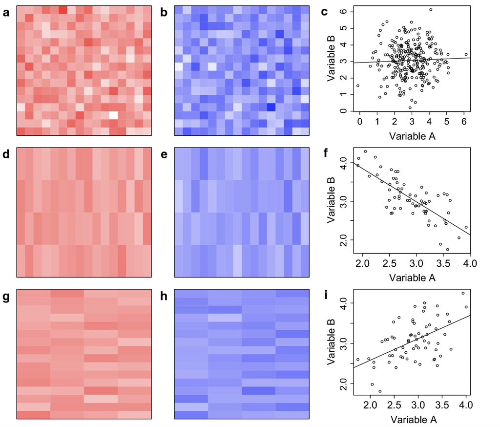

# Modifying Spatial Objects

## Changing geometries with `sf`

## Revisiting `predicates` and `measures`

- **Predicates**: evaluate a logical statement asserting that a property is `TRUE`
- **Measures**: return a numeric value with units based on the units of the CRS
- Unary, binary, and n-ary distinguish how many geometries each function accepts and returns

## Transformations

- **Transformations**: create new geometries based on input geometries

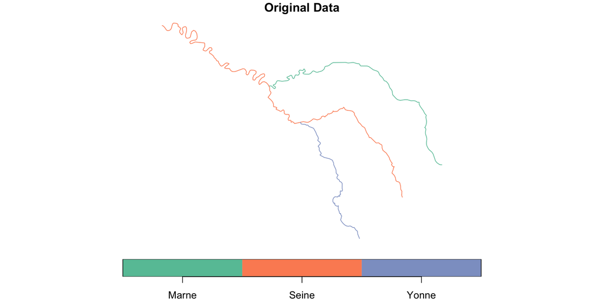

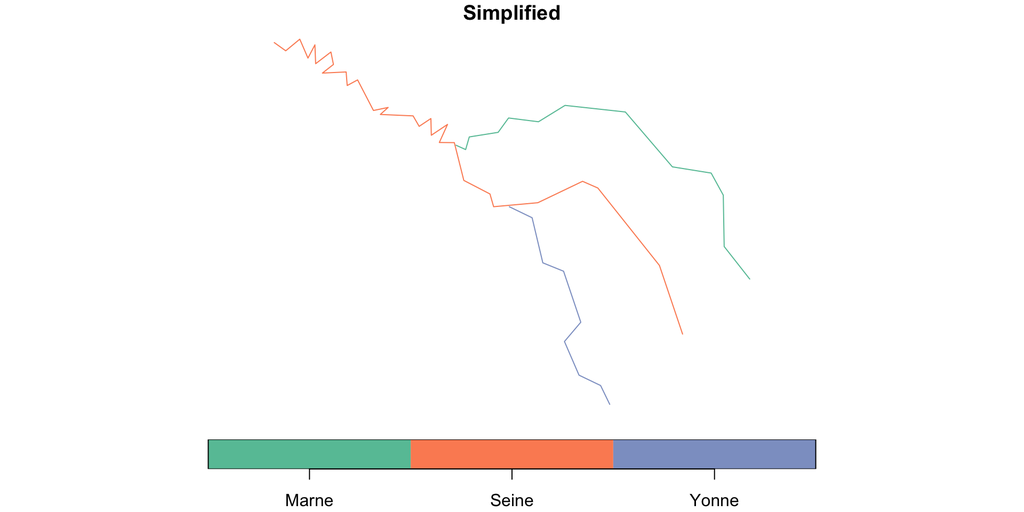

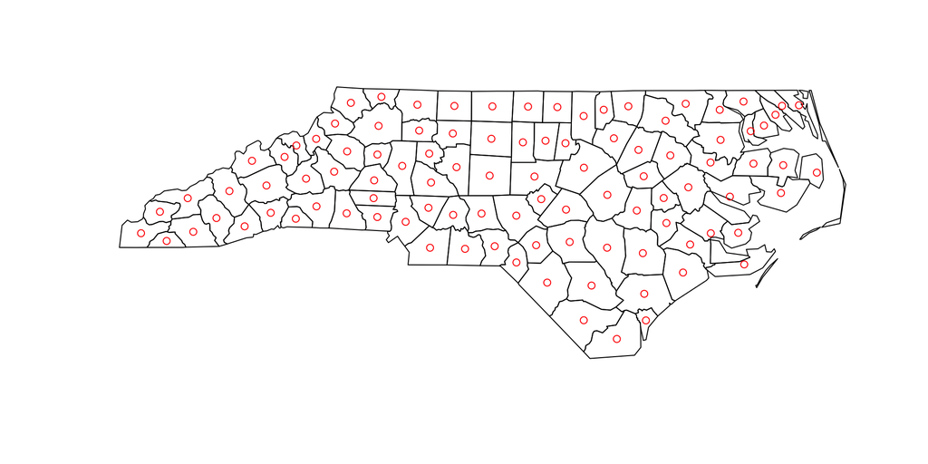

## Unary Transformations

| transformer | returns a geometry … |
| --- | --- |
| `centroid` | of type `POINT` with the geometry’s centroid |
| `buffer` | that is larger (or smaller) than the input geometry, depending on the buffer size |
| `jitter` | that was moved in space a certain amount, using a bivariate uniform distribution |
| `wrap_dateline` | cut into pieces that do no longer cover the dateline |
| `boundary` | with the boundary of the input geometry |
| `convex_hull` | that forms the convex hull of the input geometry |
| `line_merge` | after merging connecting `LINESTRING` elements of a `MULTILINESTRING` into longer `LINESTRING`s. |
| `make_valid` | that is valid |
| `node` | with added nodes to linear geometries at intersections without a node; only works on individual linear geometries |
| `point_on_surface` | with a (arbitrary) point on a surface |
| `polygonize` | of type polygon, created from lines that form a closed ring |

## Other Unary Transformations

[output not shown]

# Binary Transformers

## Binary Transformers

| function | returns | infix operator |
| --- | --- | --- |
| `intersection` | the overlapping geometries for pair of geometries | `&` |
| `union` | the combination of the geometries; removes internal boundaries and duplicate points, nodes or line pieces | `\|` |
| `difference` | the geometries of the first after removing the overlap with the second geometry | `/` |
| `sym_difference` | the combinations of the geometries after removing where they intersect; the negation (opposite) of `intersection` | `%/%` |
| `crop` | crop an sf object to a specific rectangle |  |

## Binary Transformers

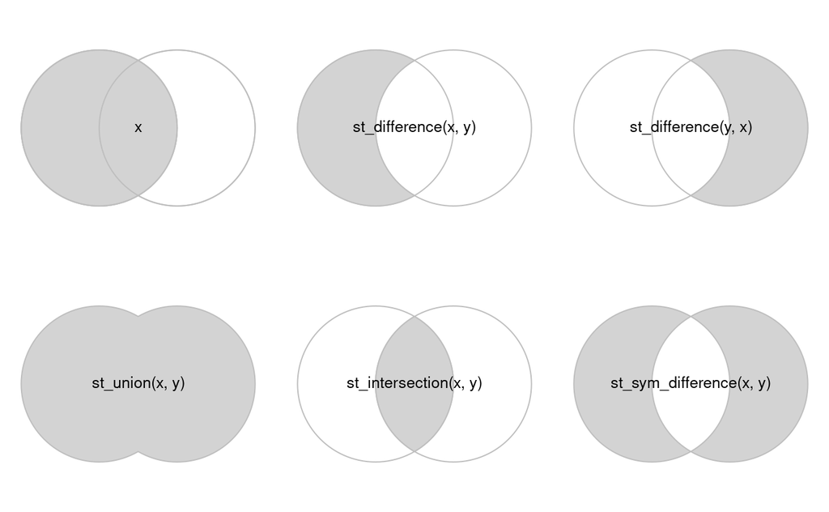

## Common Uses of Binary Transformers

- Relating partially overlapping datasets to each other
- Reducing the extent of vector objects

## N-ary Transformers

- Similar to Binary (except `st_crop`)
- `union` can be applied to a set of geometries to return its geometrical union
- `intersection` and `difference` take a single argument, but operate (sequentially) on all pairs, triples, quadruples, etc.

## Changing geometries with `terra`

- Changing pixel size with `aggregate` and `disagg` (leaves CRS unchanged)
- Dramatic changes and more sophisticated downsampling with `resample`